# RTA

```python
import pandas as pd
import numpy as np
```

```python
df = pd.read_csv('RTA Dataset.csv')
```

```python
df.shape
```

```
(12316, 32)
```

```python
df.info()
```

```
<class 'pandas.core.frame.DataFrame'>
RangeIndex: 12316 entries, 0 to 12315
Data columns (total 32 columns):
 #   Column                       Non-Null Count  Dtype
---  ------                       --------------  -----
 0   Time                         12316 non-null  object
 1   Day_of_week                  12316 non-null  object
 2   Age_band_of_driver           12316 non-null  object
 3   Sex_of_driver                12316 non-null  object
 4   Educational_level            11575 non-null  object
 5   Vehicle_driver_relation      11737 non-null  object
 6   Driving_experience           11487 non-null  object
 7   Type_of_vehicle              11366 non-null  object
 8   Owner_of_vehicle             11834 non-null  object
 9   Service_year_of_vehicle      8388 non-null   object
```

[output cut: 24 more lines]

```python
df["Defect_of_vehicle"].value_counts()
```

```
No defect    7777
7              76
5              36
Name: Defect_of_vehicle, dtype: int64
```

```python
# Columns having null values
df.isnull().sum()[df.isnull().sum()!=0]
```

```
Educational_level           741
Vehicle_driver_relation     579
Driving_experience          829
Type_of_vehicle             950
Owner_of_vehicle            482
Service_year_of_vehicle    3928
Defect_of_vehicle          4427
Area_accident_occured       239
Lanes_or_Medians            385
Road_allignment             142
Types_of_Junction           887
Road_surface_type           172
Type_of_collision           155
Vehicle_movement            308
Work_of_casuality          3198
Fitness_of_casuality       2635
dtype: int64
```

```python
import datetime

df['Time'] = pd.to_datetime(df['Time'])
```

```python
df
```

|  | Time | Day_of_week | Age_band_of_driver | Sex_of_driver | Educational_level | Vehicle_driver_relation | Driving_experience | Type_of_vehicle | Owner_of_vehicle | Service_year_of_vehicle | ... | Vehicle_movement | Casualty_class | Sex_of_casualty | Age_band_of_casualty | Casualty_severity | Work_of_casuality | Fitness_of_casuality | Pedestrian_movement | Cause_of_accident | Accident_severity |
| --- | --- | --- | --- | --- | --- | --- | --- | --- | --- | --- | --- | --- | --- | --- | --- | --- | --- | --- | --- | --- | --- |
| 0 | 2023-07-17 17:02:00 | Monday | 18-30 | Male | Above high school | Employee | 1-2yr | Automobile | Owner | Above 10yr | ... | Going straight | na | na | na | na | NaN | NaN | Not a Pedestrian | Moving Backward | Slight Injury |
| 1 | 2023-07-17 17:02:00 | Monday | 31-50 | Male | Junior high school | Employee | Above 10yr | Public (> 45 seats) | Owner | 5-10yrs | ... | Going straight | na | na | na | na | NaN | NaN | Not a Pedestrian | Overtaking | Slight Injury |
| 2 | 2023-07-17 17:02:00 | Monday | 18-30 | Male | Junior high school | Employee | 1-2yr | Lorry (41?100Q) | Owner | NaN | ... | Going straight | Driver or rider | Male | 31-50 | 3 | Driver | NaN | Not a Pedestrian | Changing lane to the left | Serious Injury |
| 3 | 2023-07-17 01:06:00 | Sunday | 18-30 | Male | Junior high school | Employee | 5-10yr | Public (> 45 seats) | Governmental | NaN | ... | Going straight | Pedestrian | Female | 18-30 | 3 | Driver | Normal | Not a Pedestrian | Changing lane to the right | Slight Injury |
| 4 | 2023-07-17 01:06:00 | Sunday | 18-30 | Male | Junior high school | Employee | 2-5yr | NaN | Owner | 5-10yrs | ... | Going straight | na | na | na | na | NaN | NaN | Not a Pedestrian | Overtaking | Slight Injury |
| ... | ... | ... | ... | ... | ... | ... | ... | ... | ... | ... | ... | ... | ... | ... | ... | ... | ... | ... | ... | ... | ... |
| 12311 | 2023-07-17 16:15:00 | Wednesday | 31-50 | Male | NaN | Employee | 2-5yr | Lorry (11?40Q) | Owner | NaN | ... | Going straight | na | na | na | na | Driver | Normal | Not a Pedestrian | No distancing | Slight Injury |
| 12312 | 2023-07-17 18:00:00 | Sunday | Unknown | Male | Elementary school | Employee | 5-10yr | Automobile | Owner | NaN | ... | Other | na | na | na | na | Driver | Normal | Not a Pedestrian | No distancing | Slight Injury |
| 12313 | 2023-07-17 13:55:00 | Sunday | Over 51 | Male | Junior high school | Employee | 5-10yr | Bajaj | Owner | 2-5yrs | ... | Other | Driver or rider | Male | 31-50 | 3 | Driver | Normal | Not a Pedestrian | Changing lane to the right | Serious Injury |
| 12314 | 2023-07-17 13:55:00 | Sunday | 18-30 | Female | Junior high school | Employee | Above 10yr | Lorry (41?100Q) | Owner | 2-5yrs | ... | Other | na | na | na | na | Driver | Normal | Not a Pedestrian | Driving under the influence of drugs | Slight Injury |
| 12315 | 2023-07-17 13:55:00 | Sunday | 18-30 | Male | Junior high school | Employee | 5-10yr | Other | Owner | 2-5yrs | ... | Stopping | Pedestrian | Female | 5 | 3 | Driver | Normal | Crossing from nearside - masked by parked or s... | Changing lane to the right | Slight Injury |

12316 rows × 32 columns

```python
df.columns
```

```
Index(['Time', 'Day_of_week', 'Age_band_of_driver', 'Sex_of_driver',
       'Educational_level', 'Vehicle_driver_relation', 'Driving_experience',
       'Type_of_vehicle', 'Owner_of_vehicle', 'Service_year_of_vehicle',
       'Defect_of_vehicle', 'Area_accident_occured', 'Lanes_or_Medians',
       'Road_allignment', 'Types_of_Junction', 'Road_surface_type',
       'Road_surface_conditions', 'Light_conditions', 'Weather_conditions',
       'Type_of_collision', 'Number_of_vehicles_involved',
       'Number_of_casualties', 'Vehicle_movement', 'Casualty_class',
       'Sex_of_casualty', 'Age_band_of_casualty', 'Casualty_severity',
       'Work_of_casuality', 'Fitness_of_casuality', 'Pedestrian_movement',
       'Cause_of_accident', 'Accident_severity'],
      dtype='object')
```

```python
## Filling null values
```

```python
df_null=df.isnull().sum()[df.isnull().sum()!=0].index
```

```python
columns=list(df_null)
```

```python
df['Educational_level'].mode()[0]
```

```
'Junior high school'
```

```python
columns
```

```
['Educational_level',
 'Vehicle_driver_relation',
 'Driving_experience',
 'Type_of_vehicle',
 'Owner_of_vehicle',
 'Service_year_of_vehicle',
 'Defect_of_vehicle',
 'Area_accident_occured',
 'Lanes_or_Medians',
 'Road_allignment',
 'Types_of_Junction',
 'Road_surface_type',
 'Type_of_collision',
 'Vehicle_movement',
 'Work_of_casuality',
 'Fitness_of_casuality']
```

```python
# as all the columns are object type will fill the null values using mode

for i in columns:
    mode=df[i].mode()[0]
    print(mode)
    df[i].fillna(mode,inplace=True)
    #print(df)
```

```
Junior high school
Employee
5-10yr
Automobile
Owner
Unknown
No defect
Other
Two-way (divided with broken lines road marking)
Tangent road with flat terrain
Y Shape
Asphalt roads
Vehicle with vehicle collision
Going straight
Driver
Normal
```

```python
df.isnull().sum() # all null values are removed
```

```
Time                           0
Day_of_week                    0
Age_band_of_driver             0
Sex_of_driver                  0
Educational_level              0
Vehicle_driver_relation        0
Driving_experience             0
Type_of_vehicle                0
Owner_of_vehicle               0
Service_year_of_vehicle        0
Defect_of_vehicle              0
Area_accident_occured          0
Lanes_or_Medians               0
Road_allignment                0
Types_of_Junction              0
Road_surface_type              0
Road_surface_conditions        0
Light_conditions               0
Weather_conditions             0
Type_of_collision              0
Number_of_vehicles_involved    0
Number_of_casualties           0
Vehicle_movement               0
Casualty_class                 0
Sex_of_casualty                0
Age_band_of_casualty           0
Casualty_severity              0
Work_of_casuality              0
Fitness_of_casuality           0
Pedestrian_movement            0
Cause_of_accident              0
Accident_severity              0
dtype: int64
```

```python
df.head()
```

|  | Time | Day_of_week | Age_band_of_driver | Sex_of_driver | Educational_level | Vehicle_driver_relation | Driving_experience | Type_of_vehicle | Owner_of_vehicle | Service_year_of_vehicle | ... | Vehicle_movement | Casualty_class | Sex_of_casualty | Age_band_of_casualty | Casualty_severity | Work_of_casuality | Fitness_of_casuality | Pedestrian_movement | Cause_of_accident | Accident_severity |
| --- | --- | --- | --- | --- | --- | --- | --- | --- | --- | --- | --- | --- | --- | --- | --- | --- | --- | --- | --- | --- | --- |
| 0 | 2023-07-17 17:02:00 | Monday | 18-30 | Male | Above high school | Employee | 1-2yr | Automobile | Owner | Above 10yr | ... | Going straight | na | na | na | na | Driver | Normal | Not a Pedestrian | Moving Backward | Slight Injury |
| 1 | 2023-07-17 17:02:00 | Monday | 31-50 | Male | Junior high school | Employee | Above 10yr | Public (> 45 seats) | Owner | 5-10yrs | ... | Going straight | na | na | na | na | Driver | Normal | Not a Pedestrian | Overtaking | Slight Injury |
| 2 | 2023-07-17 17:02:00 | Monday | 18-30 | Male | Junior high school | Employee | 1-2yr | Lorry (41?100Q) | Owner | Unknown | ... | Going straight | Driver or rider | Male | 31-50 | 3 | Driver | Normal | Not a Pedestrian | Changing lane to the left | Serious Injury |
| 3 | 2023-07-17 01:06:00 | Sunday | 18-30 | Male | Junior high school | Employee | 5-10yr | Public (> 45 seats) | Governmental | Unknown | ... | Going straight | Pedestrian | Female | 18-30 | 3 | Driver | Normal | Not a Pedestrian | Changing lane to the right | Slight Injury |
| 4 | 2023-07-17 01:06:00 | Sunday | 18-30 | Male | Junior high school | Employee | 2-5yr | Automobile | Owner | 5-10yrs | ... | Going straight | na | na | na | na | Driver | Normal | Not a Pedestrian | Overtaking | Slight Injury |

5 rows × 32 columns

```python
import datetime
```

```python
df['Hour'] = df['Time'].dt.hour # extracting Hours from data
```

```python
df['Minutes'] = df['Time'].dt.minute # Extracting Minutes from data
```

```python
df.info()
```

```
<class 'pandas.core.frame.DataFrame'>
RangeIndex: 12316 entries, 0 to 12315
Data columns (total 34 columns):
 #   Column                       Non-Null Count  Dtype
---  ------                       --------------  -----
 0   Time                         12316 non-null  datetime64[ns]
 1   Day_of_week                  12316 non-null  object
 2   Age_band_of_driver           12316 non-null  object
 3   Sex_of_driver                12316 non-null  object
 4   Educational_level            12316 non-null  object
 5   Vehicle_driver_relation      12316 non-null  object
 6   Driving_experience           12316 non-null  object
 7   Type_of_vehicle              12316 non-null  object
 8   Owner_of_vehicle             12316 non-null  object
 9   Service_year_of_vehicle      12316 non-null  object
```

[output cut: 26 more lines]

```python
df.drop('Time',axis=1, inplace=True)
```

```python
df.head()
```

|  | Day_of_week | Age_band_of_driver | Sex_of_driver | Educational_level | Vehicle_driver_relation | Driving_experience | Type_of_vehicle | Owner_of_vehicle | Service_year_of_vehicle | Defect_of_vehicle | ... | Sex_of_casualty | Age_band_of_casualty | Casualty_severity | Work_of_casuality | Fitness_of_casuality | Pedestrian_movement | Cause_of_accident | Accident_severity | Hour | Minutes |
| --- | --- | --- | --- | --- | --- | --- | --- | --- | --- | --- | --- | --- | --- | --- | --- | --- | --- | --- | --- | --- | --- |
| 0 | Monday | 18-30 | Male | Above high school | Employee | 1-2yr | Automobile | Owner | Above 10yr | No defect | ... | na | na | na | Driver | Normal | Not a Pedestrian | Moving Backward | Slight Injury | 17 | 2 |
| 1 | Monday | 31-50 | Male | Junior high school | Employee | Above 10yr | Public (> 45 seats) | Owner | 5-10yrs | No defect | ... | na | na | na | Driver | Normal | Not a Pedestrian | Overtaking | Slight Injury | 17 | 2 |
| 2 | Monday | 18-30 | Male | Junior high school | Employee | 1-2yr | Lorry (41?100Q) | Owner | Unknown | No defect | ... | Male | 31-50 | 3 | Driver | Normal | Not a Pedestrian | Changing lane to the left | Serious Injury | 17 | 2 |
| 3 | Sunday | 18-30 | Male | Junior high school | Employee | 5-10yr | Public (> 45 seats) | Governmental | Unknown | No defect | ... | Female | 18-30 | 3 | Driver | Normal | Not a Pedestrian | Changing lane to the right | Slight Injury | 1 | 6 |
| 4 | Sunday | 18-30 | Male | Junior high school | Employee | 2-5yr | Automobile | Owner | 5-10yrs | No defect | ... | na | na | na | Driver | Normal | Not a Pedestrian | Overtaking | Slight Injury | 1 | 6 |

5 rows × 33 columns

# Exploratory Data Analysis

```python
import matplotlib.pyplot as plt
```

```python
cat_var=df.select_dtypes(include= ["object"]).columns
```

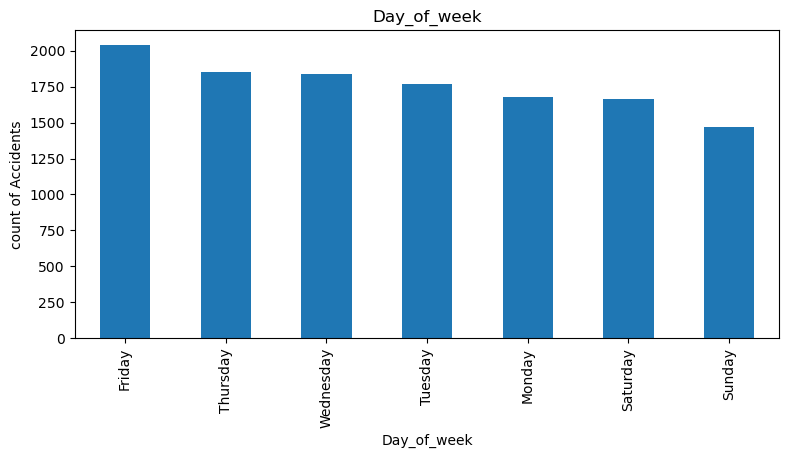

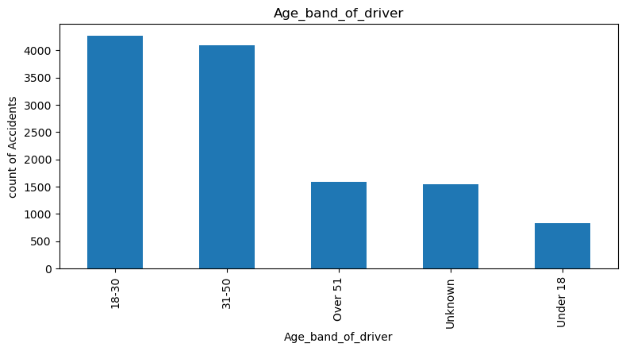

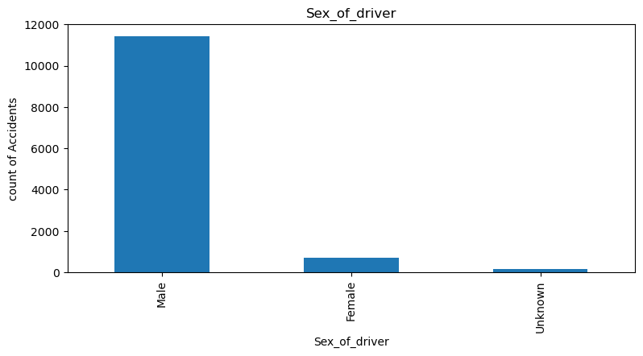

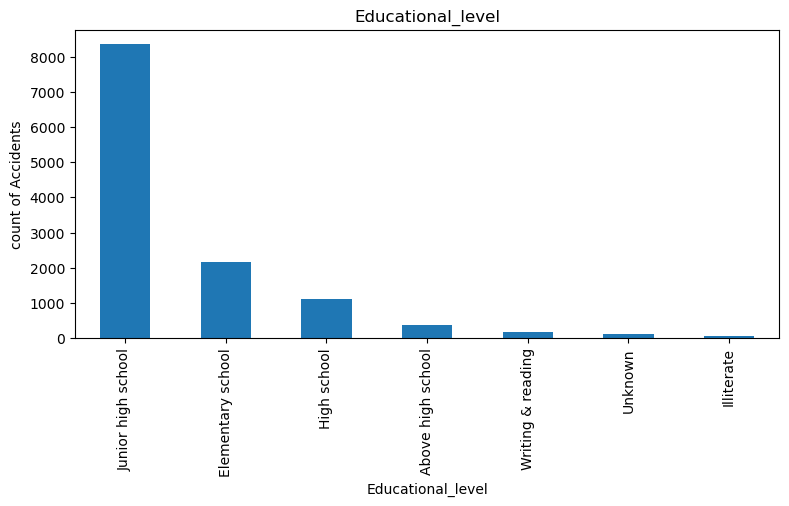

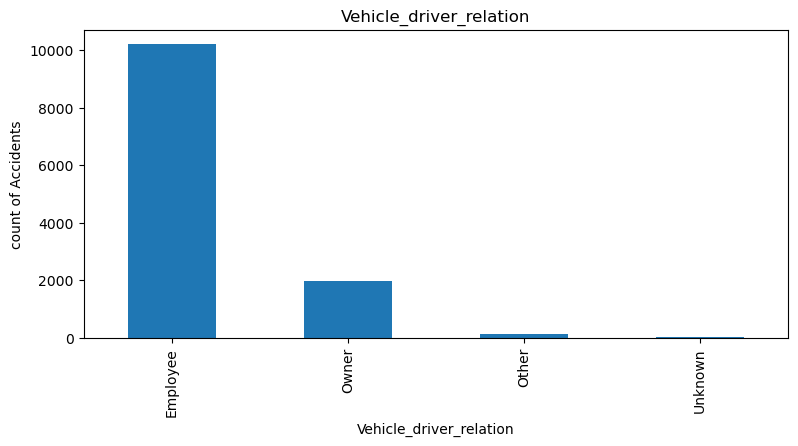

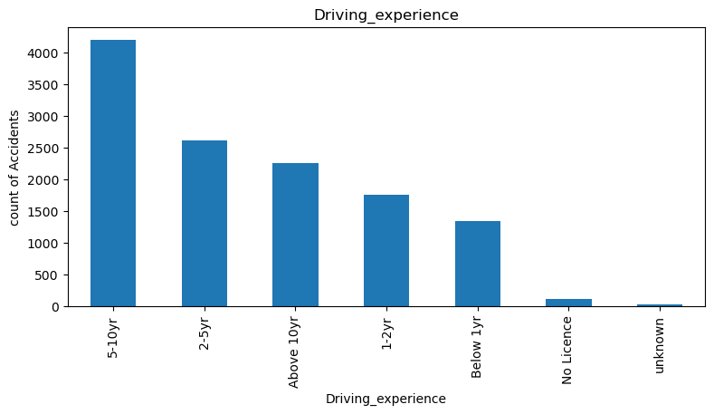

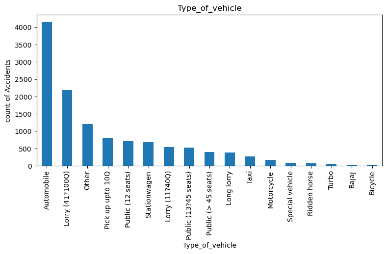

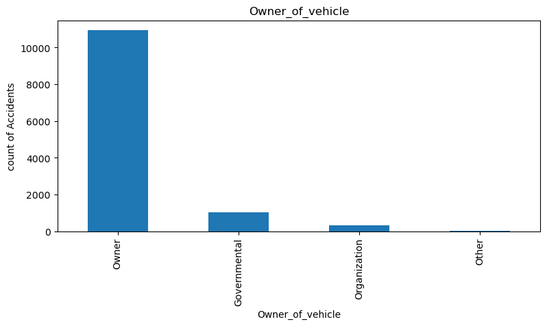

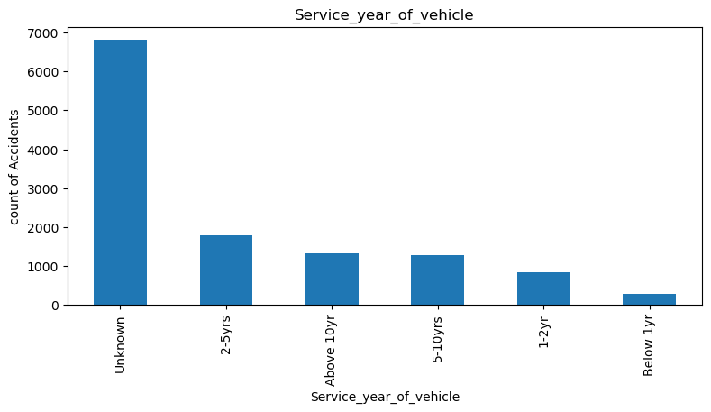

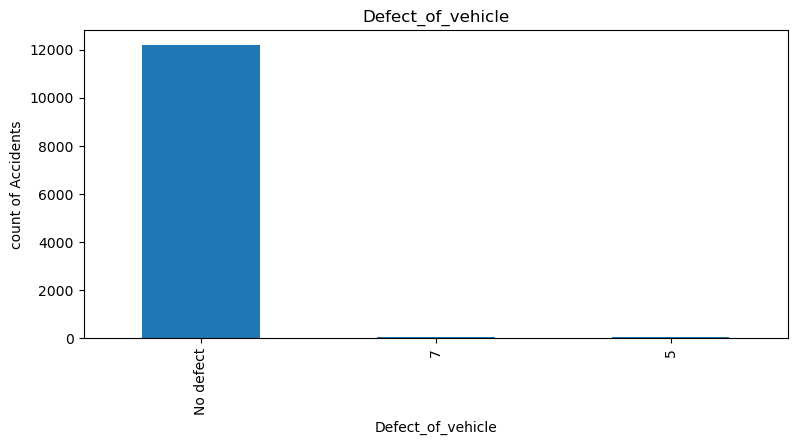

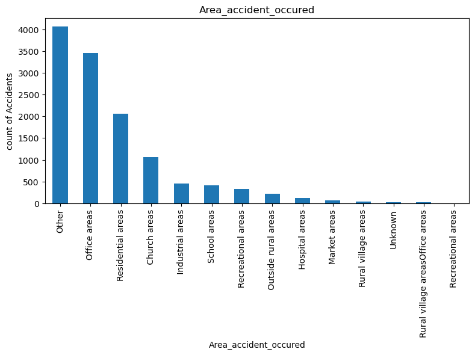

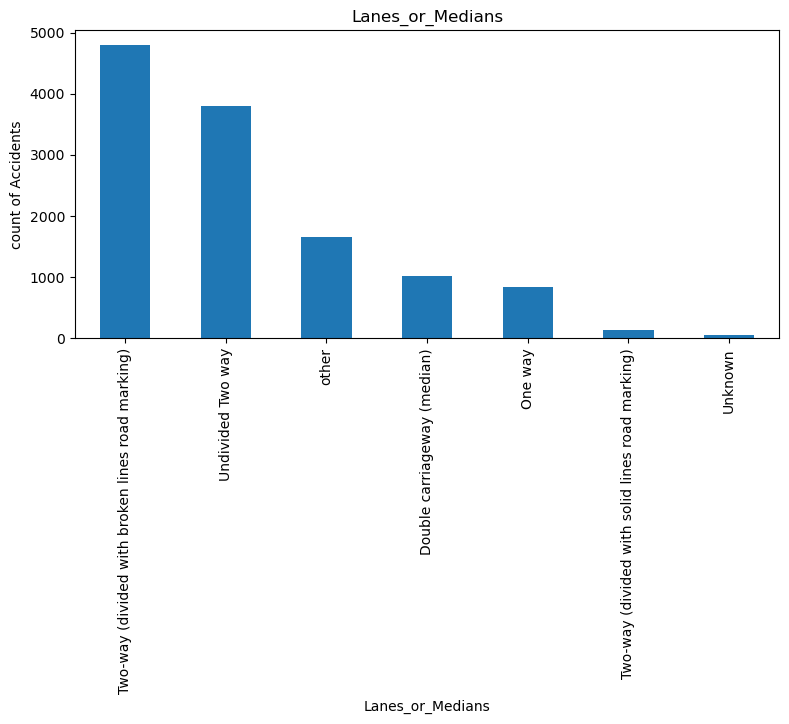

[17 more figures not shown]

```python
# plotting bar chart for each categorical variable

for column in cat_var:
    plt.figure(figsize=(20,4))
    plt.subplot(121)
    df[column].value_counts().plot(kind="bar")
    plt.xlabel(column)
    plt.ylabel("count of Accidents")
    plt.title(column)
```

**Insights:** - Lots of accidents have occured on weekly basis but mostly count of accidents are slightly high on fridays. - Age group between 18-50 years and male drivers have met with lot of accidents. - Most of the drivers have studied upto Juniour High school and are employees and most of them have 5-10 years of experience. - The type of vehicle which has lot of accidents are Automobiles. - Service year is not known for most of the vehicles but there are vehicles with 2-5 years of service and also almost a lot of vehicles has no defect. - Lot of accidents have occured on undivided two-way road or divided with broken lines. **Road Conditions: **- Most of the Accidents happend on tangent road with flat terrain and Y- Junction or No Junction. - Asphalt and dry conditioned roads have high accident counts. **Weather Conditions: **- Weather conditions were normal and on day light there are lots counts of aciidents. **Cause of accident and Casuality: **- Vehicle to Vehicle Collisions were the main cause for the accidents and most of the vehicles were going straight. - Lots of casuality class are Drivers. - The reason for most of the accidents are No distancing, changing lane from left to right or right to left, Careless driving, No priority to vehicle or pedestrians and many other reasons. - Most of the drivers who met with an accident were slightly injured and very few were seriously injured or have fatal injury.************

```python
df.info()
```

```
<class 'pandas.core.frame.DataFrame'>
RangeIndex: 12316 entries, 0 to 12315
Data columns (total 33 columns):
 #   Column                       Non-Null Count  Dtype
---  ------                       --------------  -----
 0   Day_of_week                  12316 non-null  object
 1   Age_band_of_driver           12316 non-null  object
 2   Sex_of_driver                12316 non-null  object
 3   Educational_level            12316 non-null  object
 4   Vehicle_driver_relation      12316 non-null  object
 5   Driving_experience           12316 non-null  object
 6   Type_of_vehicle              12316 non-null  object
 7   Owner_of_vehicle             12316 non-null  object
 8   Service_year_of_vehicle      12316 non-null  object
 9   Defect_of_vehicle            12316 non-null  object
```

[output cut: 25 more lines]

```python
import seaborn as sns
```

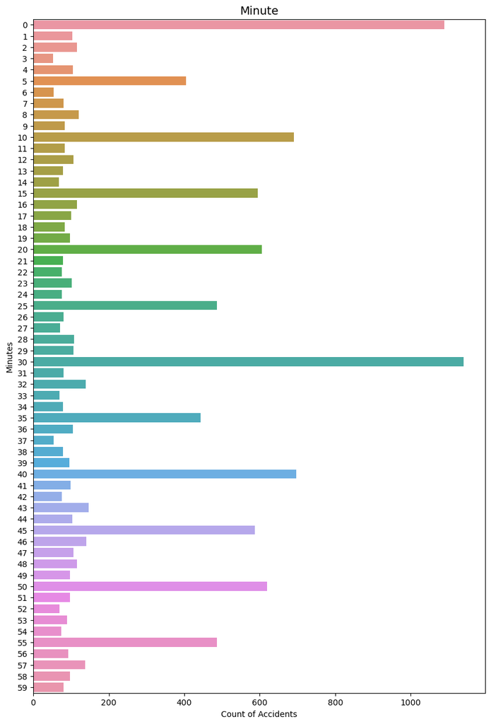

```python
plt.figure(figsize=(10,15))
sns.countplot(data=df, y='Minutes')
plt.title('Minute', fontsize=14)
plt.xlabel('Count of Accidents')
plt.ylabel('Minutes')
```

```python
# performing binning for minutes

min = list(range(5,56, 5))
def convert_minutes(x: int):
    for m in min:
        if x % m == x and x > m-5:
            return m
        if x in [56,57,58,59]:
            return 0
        if x in min+[0]:
            return x
```

```python
df['Minutes'] = df['Minutes'].apply(lambda x: convert_minutes(x))
```

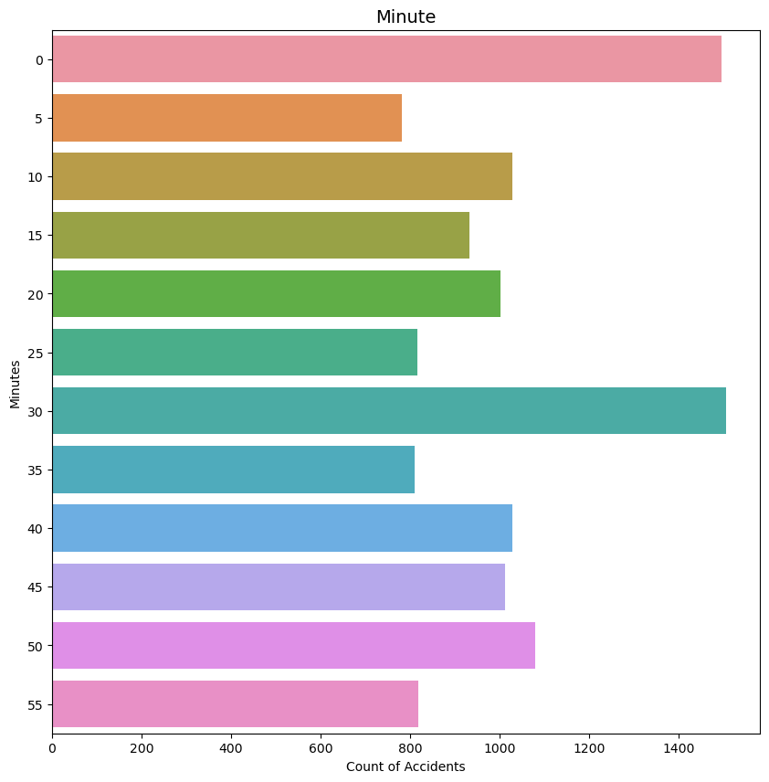

```python
plt.figure(figsize=(10,10))
sns.countplot(data=df, y='Minutes')
plt.title('Minute', fontsize=14)
plt.xlabel('Count of Accidents')
plt.ylabel('Minutes')
```

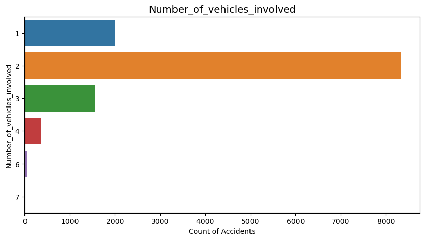

```python
plt.figure(figsize=(10,5))
sns.countplot(data=df, y='Number_of_vehicles_involved')
plt.title('Number_of_vehicles_involved', fontsize=14)
plt.xlabel('Count of Accidents')
plt.ylabel('Number_of_vehicles_involved')
```

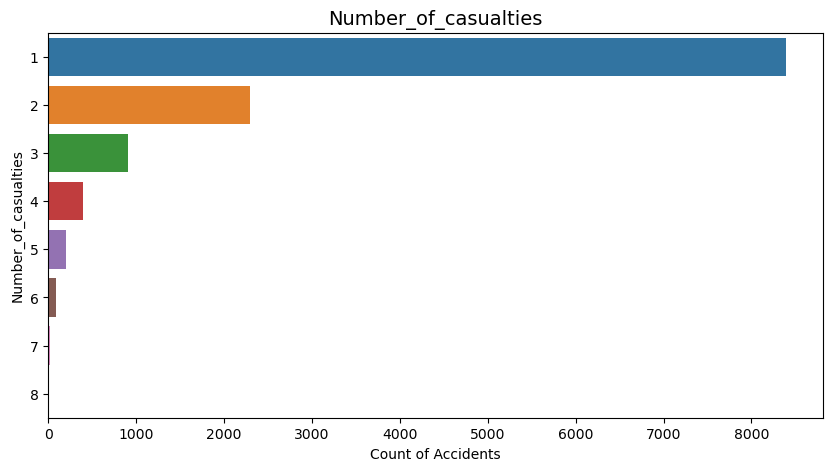

```python
plt.figure(figsize=(10,5))
sns.countplot(data=df, y='Number_of_casualties')
plt.title('Number_of_casualties', fontsize=14)
plt.xlabel('Count of Accidents')
plt.ylabel('Number_of_casualties')
```

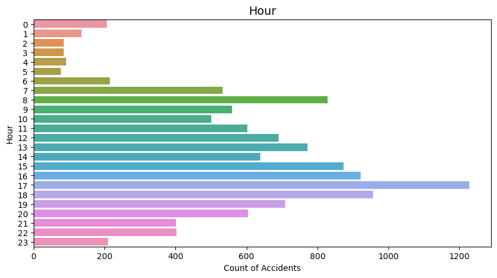

```python
plt.figure(figsize=(10,5))
sns.countplot(data=df, y='Hour')
plt.title('Hour', fontsize=14)
plt.xlabel('Count of Accidents')
plt.ylabel('Hour')
```

**Insights:**

[output not shown]

# Bivariate Analysis

```python
import seaborn as sns
```

```python
df['Number_of_vehicles_involved'].value_counts()
```

```
2    8340
1    1996
3    1568
4     363
6      42
7       7
Name: Number_of_vehicles_involved, dtype: int64
```

```python
df.columns
```

```
Index(['Day_of_week', 'Age_band_of_driver', 'Sex_of_driver',
       'Educational_level', 'Vehicle_driver_relation', 'Driving_experience',
       'Type_of_vehicle', 'Owner_of_vehicle', 'Service_year_of_vehicle',
       'Defect_of_vehicle', 'Area_accident_occured', 'Lanes_or_Medians',
       'Road_allignment', 'Types_of_Junction', 'Road_surface_type',
       'Road_surface_conditions', 'Light_conditions', 'Weather_conditions',
       'Type_of_collision', 'Number_of_vehicles_involved',
       'Number_of_casualties', 'Vehicle_movement', 'Casualty_class',
       'Sex_of_casualty', 'Age_band_of_casualty', 'Casualty_severity',
       'Work_of_casuality', 'Fitness_of_casuality', 'Pedestrian_movement',
       'Cause_of_accident', 'Accident_severity', 'Hour', 'Minutes'],
      dtype='object')
```

```python
import matplotlib.pyplot as plt
```

#### Day of week Vs Accident Severity

```python
CrosstabResult=pd.crosstab(index=df['Accident_severity'],columns=df['Day_of_week'])
print(CrosstabResult)
```

```
Day_of_week        Friday  Monday  Saturday  Sunday  Thursday  Tuesday  \
Accident_severity
Fatal injury           16      12        37      35        22       17
Serious Injury        313     204       245     190       272      257
Slight Injury        1712    1465      1384    1242      1557     1496

Day_of_week        Wednesday
Accident_severity
Fatal injury              19
Serious Injury           262
Slight Injury           1559
```

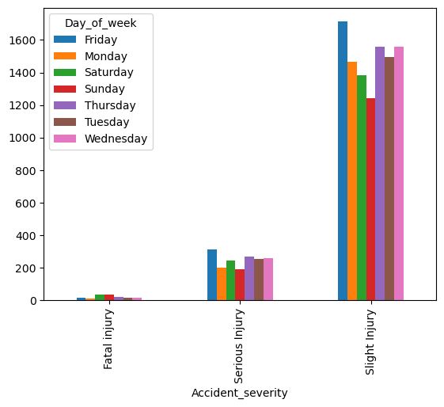

```python
CrosstabResult.plot.bar()
```

```python
# We can see that lots of accidents occured on fridays which are slightly slightly injured
# Serious injury also has occured more on fridays
```

```python
df.columns
```

```
Index(['Day_of_week', 'Age_band_of_driver', 'Sex_of_driver',
       'Educational_level', 'Vehicle_driver_relation', 'Driving_experience',
       'Type_of_vehicle', 'Owner_of_vehicle', 'Service_year_of_vehicle',
       'Defect_of_vehicle', 'Area_accident_occured', 'Lanes_or_Medians',
       'Road_allignment', 'Types_of_Junction', 'Road_surface_type',
       'Road_surface_conditions', 'Light_conditions', 'Weather_conditions',
       'Type_of_collision', 'Number_of_vehicles_involved',
       'Number_of_casualties', 'Vehicle_movement', 'Casualty_class',
       'Sex_of_casualty', 'Age_band_of_casualty', 'Casualty_severity',
       'Work_of_casuality', 'Fitness_of_casuality', 'Pedestrian_movement',
       'Cause_of_accident', 'Accident_severity', 'Hour', 'Minutes'],
      dtype='object')
```

#### Accident Severity Vs Sex of drivers

```python
CrosstabResult=pd.crosstab(index=df['Accident_severity'],columns=df['Sex_of_driver'])
print(CrosstabResult)
```

```
Sex_of_driver      Female  Male  Unknown
Accident_severity
Fatal injury            5   152        1
Serious Injury        104  1621       18
Slight Injury         592  9664      159
```

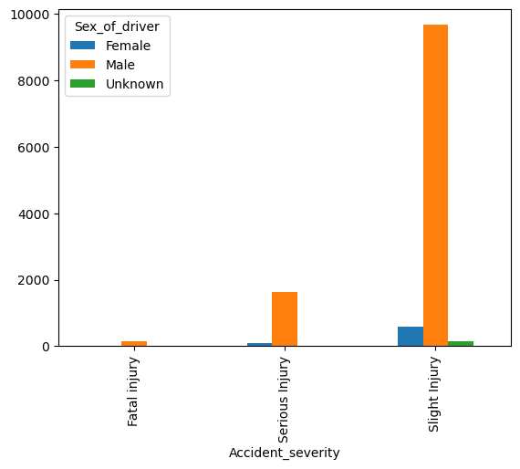

```python
CrosstabResult.plot.bar()
```

```python
# Most of the accidents are of males and are slightly injured
```

#### Age band of drivers Vs Accident severity

```
Age_band_of_driver  18-30  31-50  Over 51  Under 18  Unknown
Accident_severity
Fatal injury           62     54       24        12        6
Serious Injury        604    541      257       169      172
Slight Injury        3605   3492     1304       644     1370
```

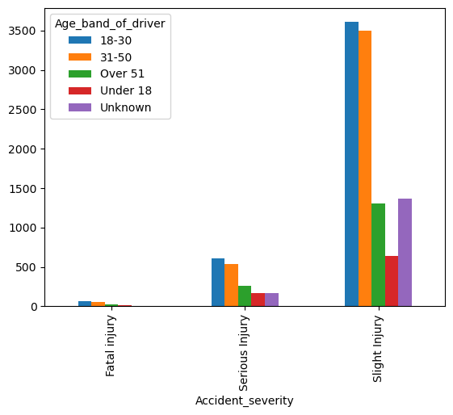

```python
CrosstabResult=pd.crosstab(index=df['Accident_severity'],columns=df['Age_band_of_driver'])
print(CrosstabResult)
CrosstabResult.plot.bar()
```

```python
df.columns
```

```
Index(['Day_of_week', 'Age_band_of_driver', 'Sex_of_driver',
       'Educational_level', 'Vehicle_driver_relation', 'Driving_experience',
       'Type_of_vehicle', 'Owner_of_vehicle', 'Service_year_of_vehicle',
       'Defect_of_vehicle', 'Area_accident_occured', 'Lanes_or_Medians',
       'Road_allignment', 'Types_of_Junction', 'Road_surface_type',
       'Road_surface_conditions', 'Light_conditions', 'Weather_conditions',
       'Type_of_collision', 'Number_of_vehicles_involved',
       'Number_of_casualties', 'Vehicle_movement', 'Casualty_class',
       'Sex_of_casualty', 'Age_band_of_casualty', 'Casualty_severity',
       'Work_of_casuality', 'Fitness_of_casuality', 'Pedestrian_movement',
       'Cause_of_accident', 'Accident_severity', 'Hour', 'Minutes'],
      dtype='object')
```

```
Educational_level  Above high school  Elementary school  High school  \
Accident_severity
Fatal injury                       5                 24           15
Serious Injury                    53                314          146
Slight Injury                    304               1825          949

Educational_level  Illiterate  Junior high school  Unknown  Writing & reading
Accident_severity
Fatal injury                0                 111        0                  3
Serious Injury              6                1182       20                 22
Slight Injury              39                7067       80                151
```

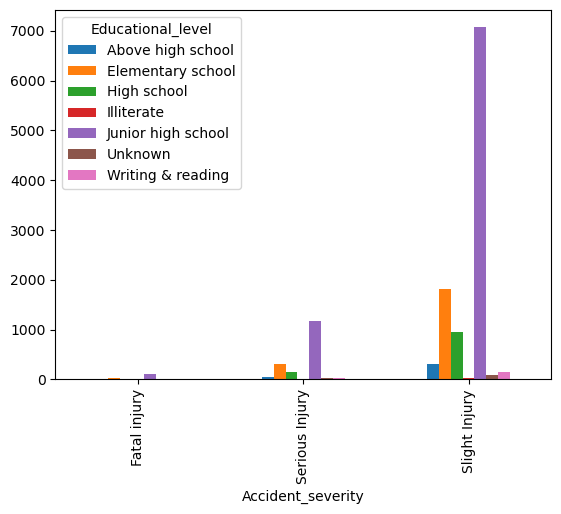

```python
CrosstabResult=pd.crosstab(index=df['Accident_severity'],columns=df['Educational_level'])
print(CrosstabResult)
CrosstabResult.plot.bar()
```

```
Vehicle_driver_relation  Employee  Other  Owner  Unknown
Accident_severity
Fatal injury                  123      1     34        0
Serious Injury               1441     14    287        1
Slight Injury                8642    108   1652       13
```

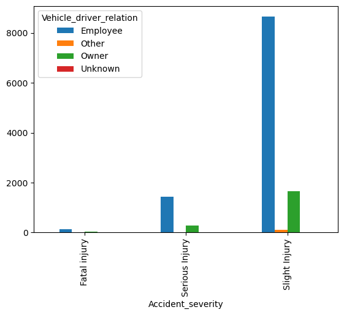

```python
CrosstabResult=pd.crosstab(index=df['Accident_severity'],columns=df['Vehicle_driver_relation'])
print(CrosstabResult)
CrosstabResult.plot.bar()
```

```
Driving_experience  1-2yr  2-5yr  5-10yr  Above 10yr  Below 1yr  No Licence  \
Accident_severity
Fatal injury           21     46      54          29          7           0
Serious Injury        228    381     585         323        207          13
Slight Injury        1507   2186    3553        1910       1128         105

Driving_experience  unknown
Accident_severity
Fatal injury              1
Serious Injury            6
Slight Injury            26
```

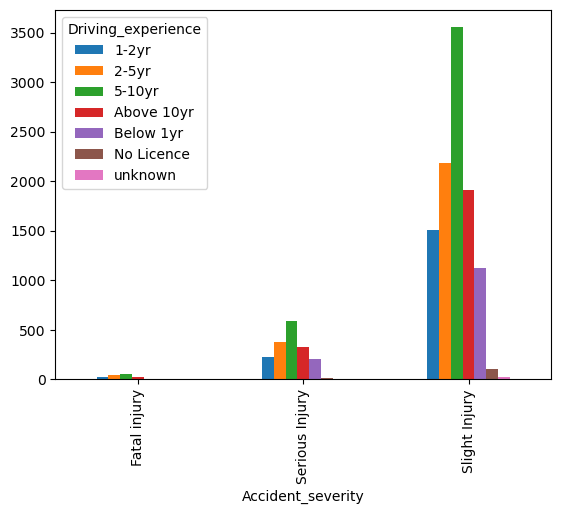

```python
CrosstabResult=pd.crosstab(index=df['Accident_severity'],columns=df['Driving_experience'])
print(CrosstabResult)
CrosstabResult.plot.bar()
```

```python
df.columns
```

```
Index(['Day_of_week', 'Age_band_of_driver', 'Sex_of_driver',
       'Educational_level', 'Vehicle_driver_relation', 'Driving_experience',
       'Type_of_vehicle', 'Owner_of_vehicle', 'Service_year_of_vehicle',
       'Defect_of_vehicle', 'Area_accident_occured', 'Lanes_or_Medians',
       'Road_allignment', 'Types_of_Junction', 'Road_surface_type',
       'Road_surface_conditions', 'Light_conditions', 'Weather_conditions',
       'Type_of_collision', 'Number_of_vehicles_involved',
       'Number_of_casualties', 'Vehicle_movement', 'Casualty_class',
       'Sex_of_casualty', 'Age_band_of_casualty', 'Casualty_severity',
       'Work_of_casuality', 'Fitness_of_casuality', 'Pedestrian_movement',
       'Cause_of_accident', 'Accident_severity', 'Hour', 'Minutes'],
      dtype='object')
```

```
Type_of_vehicle    Automobile  Bajaj  Bicycle  Long lorry  Lorry (11?40Q)  \
Accident_severity
Fatal injury               51      0        0           4               7
Serious Injury            588      3        1          67              99
Slight Injury            3516     26       20         312             435

Type_of_vehicle    Lorry (41?100Q)  Motorcycle  Other  Pick up upto 10Q  \
Accident_severity
Fatal injury                    26           3     16                15
Serious Injury                 280          29    138               132
Slight Injury                 1880         145   1054               664

Type_of_vehicle    Public (12 seats)  Public (13?45 seats)  \
Accident_severity
Fatal injury                       9                    11
Serious Injury                    95                    84
Slight Injury                    607                   437

Type_of_vehicle    Public (> 45 seats)  Ridden horse  Special vehicle  \
Accident_severity
Fatal injury                         2             0                1
Serious Injury                      55            11               17
Slight Injury                      347            65               66

Type_of_vehicle    Stationwagen  Taxi  Turbo
Accident_severity
Fatal injury                  8     5      0
Serious Injury               99    37      8
Slight Injury               580   223     38
```

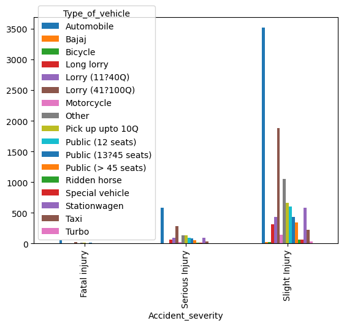

```python
CrosstabResult=pd.crosstab(index=df['Accident_severity'],columns=df['Type_of_vehicle'])
print(CrosstabResult)
CrosstabResult.plot.bar()
```

```
Owner_of_vehicle   Governmental  Organization  Other  Owner
Accident_severity
Fatal injury                 16             4      0    138
Serious Injury              131            38      1   1573
Slight Injury               894           270     21   9230
```

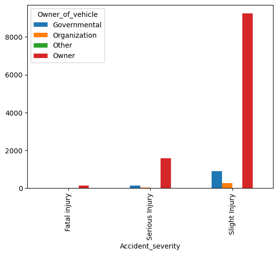

```python
CrosstabResult=pd.crosstab(index=df['Accident_severity'],columns=df['Owner_of_vehicle'])
print(CrosstabResult)
CrosstabResult.plot.bar()
```

```
Service_year_of_vehicle  1-2yr  2-5yrs  5-10yrs  Above 10yr  Below 1yr  \
Accident_severity
Fatal injury                 9      28       16          12          6
Serious Injury             111     253      191         186         43
Slight Injury              707    1511     1073        1126        233

Service_year_of_vehicle  Unknown
Accident_severity
Fatal injury                  87
Serious Injury               959
Slight Injury               5765
```

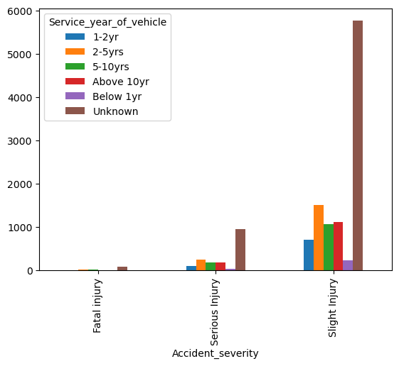

```python
CrosstabResult=pd.crosstab(index=df['Accident_severity'],columns=df['Service_year_of_vehicle'])
print(CrosstabResult)
CrosstabResult.plot.bar()
```

```
Defect_of_vehicle   5   7  No defect
Accident_severity
Fatal injury        0   0        158
Serious Injury      6  14       1723
Slight Injury      30  62      10323
```

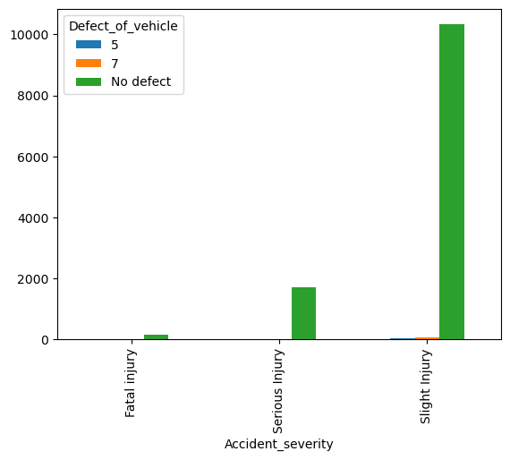

```python
CrosstabResult=pd.crosstab(index=df['Accident_severity'],columns=df['Defect_of_vehicle'])
print(CrosstabResult)
CrosstabResult.plot.bar()
```

```
Area_accident_occured    Market areas    Recreational areas   Church areas  \
Accident_severity
Fatal injury                        3                     8             10
Serious Injury                      7                    39            141
Slight Injury                      53                   280            909

Area_accident_occured   Hospital areas   Industrial areas  \
Accident_severity
Fatal injury                         0                  6
Serious Injury                      12                 60
Slight Injury                      109                390

Area_accident_occured   Outside rural areas  Office areas  Other  \
Accident_severity
Fatal injury                              1            39     46
Serious Injury                           40           475    580
Slight Injury                           177          2937   3432

Area_accident_occured  Recreational areas  Residential areas  \
Accident_severity
Fatal injury                            0                 37
Serious Injury                          1                324
Slight Injury                           0               1699

Area_accident_occured  Rural village areas  Rural village areasOffice areas  \
Accident_severity
Fatal injury                             1                                0
Serious Injury                           2                                6
Slight Injury                           41                               14

Area_accident_occured  School areas  Unknown
Accident_severity
Fatal injury                      5        2
Serious Injury                   54        2
Slight Injury                   356       18
```

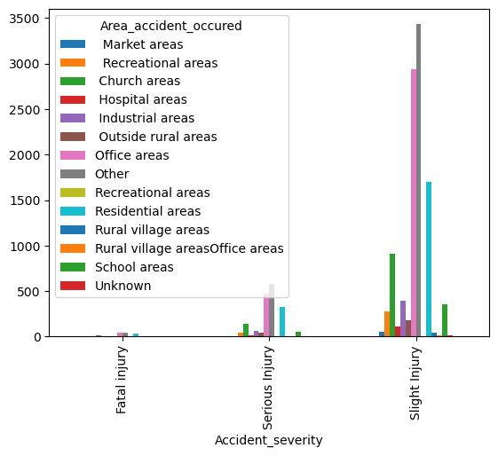

```python
CrosstabResult=pd.crosstab(index=df['Accident_severity'],columns=df['Area_accident_occured'])
print(CrosstabResult)
CrosstabResult.plot.bar()
```

```
Lanes_or_Medians   Double carriageway (median)  One way  \
Accident_severity
Fatal injury                                 7       12
Serious Injury                             132      114
Slight Injury                              881      719

Lanes_or_Medians   Two-way (divided with broken lines road marking)  \
Accident_severity
Fatal injury                                                     54
Serious Injury                                                  704
Slight Injury                                                  4038

Lanes_or_Medians   Two-way (divided with solid lines road marking)  \
Accident_severity
Fatal injury                                                     1
Serious Injury                                                  21
Slight Injury                                                  120

Lanes_or_Medians   Undivided Two way  Unknown  other
Accident_severity
Fatal injury                      62        0     22
Serious Injury                   524        6    242
Slight Injury                   3210       51   1396
```

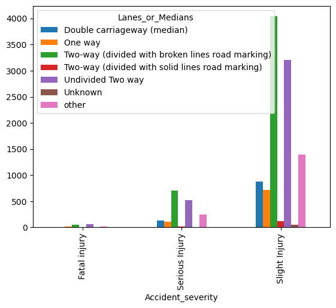

```python
CrosstabResult=pd.crosstab(index=df['Accident_severity'],columns=df['Lanes_or_Medians'])
print(CrosstabResult)
CrosstabResult.plot.bar()
```

```
Road_allignment    Escarpments  Gentle horizontal curve  Sharp reverse curve  \
Accident_severity
Fatal injury                 1                        3                    0
Serious Injury              14                       20                    9
Slight Injury               98                      140                   48

Road_allignment    Steep grade downward with mountainous terrain  \
Accident_severity
Fatal injury                                                   4
Serious Injury                                                63
Slight Injury                                                362

Road_allignment    Steep grade upward with mountainous terrain  \
Accident_severity
Fatal injury                                                 1
Serious Injury                                               5
Slight Injury                                               13

Road_allignment    Tangent road with flat terrain  \
Accident_severity
Fatal injury                                  142
Serious Injury                               1488
Slight Injury                                8971

Road_allignment    Tangent road with mild grade and flat terrain  \
Accident_severity
Fatal injury                                                   2
Serious Injury                                                77
Slight Injury                                                422

Road_allignment    Tangent road with mountainous terrain and  \
Accident_severity
Fatal injury                                               4
Serious Injury                                            61
Slight Injury                                            331

Road_allignment    Tangent road with rolling terrain
Accident_severity
Fatal injury                                       1
Serious Injury                                     6
Slight Injury                                     30
```

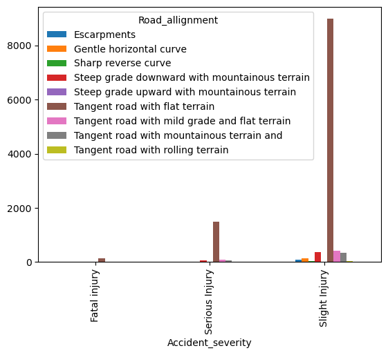

```python
CrosstabResult=pd.crosstab(index=df['Accident_severity'],columns=df['Road_allignment'])
print(CrosstabResult)
CrosstabResult.plot.bar()
```

```
Types_of_Junction  Crossing  No junction  O Shape  Other  T Shape  Unknown  \
Accident_severity
Fatal injury             12           71        1      2        0        2
Serious Injury          245          581       26     83        7       26
Slight Injury          1920         3185      137    360       53      163

Types_of_Junction  X Shape  Y Shape
Accident_severity
Fatal injury             0       70
Serious Injury           0      775
Slight Injury           12     4585
```

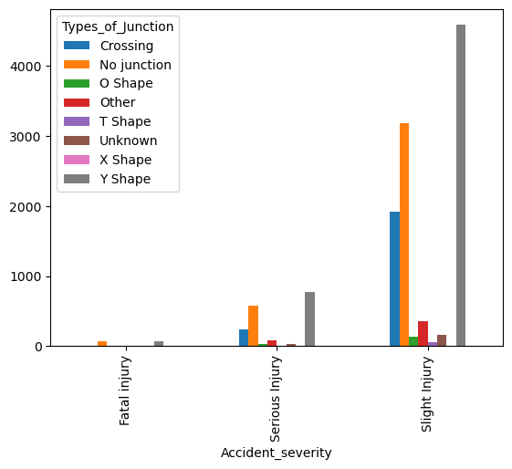

```python
CrosstabResult=pd.crosstab(index=df['Accident_severity'],columns=df['Types_of_Junction'])
print(CrosstabResult)
CrosstabResult.plot.bar()
```

```
Road_surface_type  Asphalt roads  Asphalt roads with some distress  \
Accident_severity
Fatal injury                 149                                 1
Serious Injury              1616                                 7
Slight Injury               9703                                73

Road_surface_type  Earth roads  Gravel roads  Other
Accident_severity
Fatal injury                 7             0      1
Serious Injury              49            45     26
Slight Injury              302           197    140
```

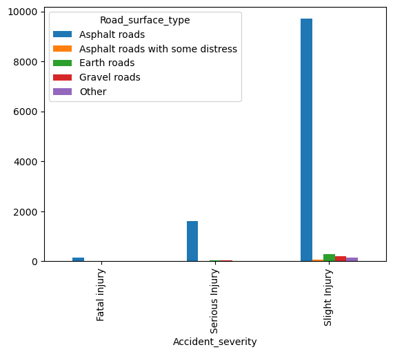

```python
CrosstabResult=pd.crosstab(index=df['Accident_severity'],columns=df['Road_surface_type'])
print(CrosstabResult)
CrosstabResult.plot.bar()
```